# Class4DataAnalysis

Emily

February 13, 2018

Introduction:

This is a project to examine speech data from a study that followed the symptom progression of patients with Parkinsons disease.

Data:

Original paper: A Tsanas, MA Little, PE McSharry, LO Ramig (2009) ‘Accurate telemonitoring of Parkinson.s disease progression by non-invasive speech tests’, IEEE Transactions on Biomedical Engineering (to appear).

Retrieved from UCL Machine Learning Database: https://archive.ics.uci.edu/ml/datasets/Parkinsons+Telemonitoring

ATTRIBUTE INFORMATION:

subject# - Integer that uniquely identifies each subject age - Subject age sex - Subject gender ‘0’ - male, ‘1’ - female test_time - Time since recruitment into the trial. The integer part is the number of days since recruitment. motor_UPDRS - Clinician’s motor UPDRS score, linearly interpolated total_UPDRS - Clinician’s total UPDRS score, linearly interpolated Jitter(%),Jitter(Abs),Jitter:RAP,Jitter:PPQ5,Jitter:DDP - Several measures of variation in fundamental frequency Shimmer,Shimmer(dB),Shimmer:APQ3,Shimmer:APQ5,Shimmer:APQ11,Shimmer:DDA - Several measures of variation in amplitude NHR,HNR - Two measures of ratio of noise to tonal components in the voice RPDE - A nonlinear dynamical complexity measure DFA - Signal fractal scaling exponent PPE - A nonlinear measure of fundamental frequency variation

```r
library(DataPrep)
data("parkinsons_updrs_data") #retrieves from data folder

library(DT)
datatable(head(parkinsons_updrs_data))
```

|  | subject# | age | sex | test_time | motor_UPDRS | total_UPDRS | Jitter(%) | Jitter(Abs) | Jitter:RAP | Jitter:PPQ5 | Jitter:DDP | Shimmer | Shimmer(dB) | Shimmer:APQ3 | Shimmer:APQ5 | Shimmer:APQ11 | Shimmer:DDA | NHR | HNR | RPDE | DFA | PPE |
| --- | --- | --- | --- | --- | --- | --- | --- | --- | --- | --- | --- | --- | --- | --- | --- | --- | --- | --- | --- | --- | --- | --- |
| 1 | 1 | 72 | 0 | 5.6431 | 28.199 | 34.398 | 0.00662 | 3.38e-05 | 0.00401 | 0.00317 | 0.01204 | 0.02565 | 0.23 | 0.01438 | 0.01309 | 0.01662 | 0.04314 | 0.01429 | 21.64 | 0.41888 | 0.54842 | 0.16006 |
| 2 | 1 | 72 | 0 | 12.666 | 28.447 | 34.894 | 0.003 | 1.68e-05 | 0.00132 | 0.0015 | 0.00395 | 0.02024 | 0.179 | 0.00994 | 0.01072 | 0.01689 | 0.02982 | 0.011112 | 27.183 | 0.43493 | 0.56477 | 0.1081 |
| 3 | 1 | 72 | 0 | 19.681 | 28.695 | 35.389 | 0.00481 | 2.462e-05 | 0.00205 | 0.00208 | 0.00616 | 0.01675 | 0.181 | 0.00734 | 0.00844 | 0.01458 | 0.02202 | 0.02022 | 23.047 | 0.46222 | 0.54405 | 0.21014 |
| 4 | 1 | 72 | 0 | 25.647 | 28.905 | 35.81 | 0.00528 | 2.657e-05 | 0.00191 | 0.00264 | 0.00573 | 0.02309 | 0.327 | 0.01106 | 0.01265 | 0.01963 | 0.03317 | 0.027837 | 24.445 | 0.4873 | 0.57794 | 0.33277 |
| 5 | 1 | 72 | 0 | 33.642 | 29.187 | 36.375 | 0.00335 | 2.014e-05 | 0.00093 | 0.0013 | 0.00278 | 0.01703 | 0.176 | 0.00679 | 0.00929 | 0.01819 | 0.02036 | 0.011625 | 26.126 | 0.47188 | 0.56122 | 0.19361 |
| 6 | 1 | 72 | 0 | 40.652 | 29.435 | 36.87 | 0.00353 | 2.29e-05 | 0.00119 | 0.00159 | 0.00357 | 0.02227 | 0.214 | 0.01006 | 0.01337 | 0.02263 | 0.03019 | 0.009438 | 22.946 | 0.53949 | 0.57243 | 0.195 |

Research Question:

Is there a correlation between speech jitter and motor score among Parkinson’s patients?

Reseach Plan:

1. Run a linear model of jitter and motor score

```r
myModel = lm(parkinsons_updrs_data$motor_UPDRS[1:149] ~ parkinsons_updrs_data$`Jitter(Abs)`[1:149])
```

2. Look at the r-squared value

```r
myModelRSquare = summary(myModel)$r.squared
myModelRSquare
```

```
## [1] 0.0009100949
```

3. Plot the data!

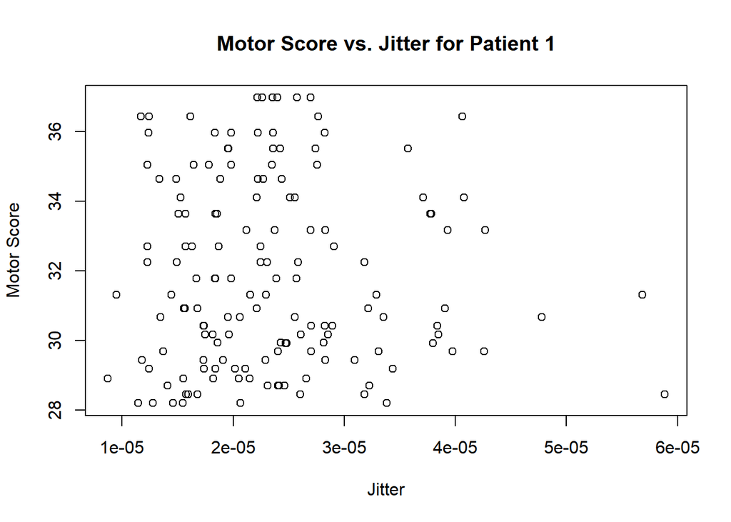

```r
myModelPlot = plot(motor_UPDRS[1:149] ~ `Jitter(Abs)`[1:149], parkinsons_updrs_data, main = "Motor Score vs. Jitter for Patient 1", xlab = "Jitter", ylab = "Motor Score")
```

```r
#need to go back and take average values for each patient and plot those!!!
```